# IE 360 PROJECT REPORT

## Group 1 : Ali Can Şahin, Selin Coşkun, Devrim Karadeniz

## 07.06.2022

## INTRODUCTION

The main purpose of this project is to forecast the hourly solar power production in KIVANC 2 GES solar power plant located in Gulnar, Mersin (between 36-37° north latitude and 33-35° east longitude). The forecast is done for the dates between 25th of May and 3rd of June (24 hours of forecast for each day). The data used for every day's production includes the production information until two days before, therefore the data is updated every day in the respective date range. Detailed information about KIVANC 2 and its google earth link is provided below : https://www.kivancenerji.com.tr/kivanc2ges.html https://www.enerjiatlasi.com/gunes/kivanc-2-ges.html https://earth.google.com/web/search/G%C3%BClnar,+Mersin/@36.53293553,33.25506549,1133.49566978a,3417.68721644d,35y,-10.21136707h,0.67542784t,0r/data=CigiJgokCbDmFAthQkNAEbdEevHBMENAGY72bhshJkBAIVzzZJJPBEBA

In the forecasting model, together with the production data of the previous dates, weather information of the respective location is also used. This weather information includes the temperature, relative humidity, downward shortwave radiation flux and cloud cover data. These data are kept in TEMP, REL_HUMIDITY, DSWRF, and CLOUD_LOW_LAYER respectively. TEMP shows the temperature of the location and high temperatures are known to decrease the solar power production efficiency. According to REL_HUMIDITY, the cloudy or rainy days can be identified. In cloudy or rainy days, the production volume decreases. DSWRF indicates the total amount of shortwave radiation including direct and diffuse radiation that reaches the Earth’s surface. CLOUD_LOW_LAYER designates the percentage of cloud cover in the atmosphere for low level cloud types. The weather data are given in long format including the weather information for 9 different coordinates near KIVANC 2 GES solar power plant.

Before starting to modeling part, it is realised that in the given data file some dates were empty in terms of production amount. For the sake of the model, the production amount for these dates are determined by the average of 3 days before and 3 days after values of specified date for each corresponding hour.

After that, to analyse data some visualisation techniques are used. Firstly, total daily production volumes are found and plotted.

```r
#install.packages('https://cran.r-project.org/src/contrib/Archive/urca//urca_1.2-8.tar.gz')
setwd('C:/Users/alica/OneDrive/Masaüstü/ali belgeler/BOUN/3.Sınıf/2.DÖNEM/IE 360/PROJECT')
#install.packages('https://cran.r-project.org/src/contrib/Archive/data.table/data.table_1.11.0.tar.gz')
library(data.table)
library(lubridate)
library(ggplot2)
#install.packages('https://cran.r-project.org/src/contrib/Archive/zoo/zoo_1.7-14.tar.gz')
library(zoo)
library(forecast)
#install.packages('corrplot')
library(corrplot)
library(urca)
```

```r
weather = read.csv('2022-06-02_weather.csv')
weather$date = ymd(weather$date)
str(weather)
head(weather)
tail(weather)
```

```
'data.frame':	425088 obs. of  6 variables:
 $ date    : Date, format: "2021-02-01" "2021-02-01" ...
 $ hour    : int  0 1 2 3 4 5 6 7 8 9 ...
 $ lat     : num  36.2 36.2 36.2 36.2 36.2 ...
 $ lon     : num  33 33 33 33 33 33 33 33 33 33 ...
 $ variable: Factor w/ 4 levels "CLOUD_LOW_LAYER",..: 2 2 2 2 2 2 2 2 2 2 ...
 $ value   : num  0 0 0 0 0 0 0 0 0 3 ...
```

| date | hour | lat | lon | variable | value |
| --- | --- | --- | --- | --- | --- |
| 2021-02-01 | 0 | 36.25 | 33 | DSWRF | 0 |
| 2021-02-01 | 1 | 36.25 | 33 | DSWRF | 0 |
| 2021-02-01 | 2 | 36.25 | 33 | DSWRF | 0 |
| 2021-02-01 | 3 | 36.25 | 33 | DSWRF | 0 |
| 2021-02-01 | 4 | 36.25 | 33 | DSWRF | 0 |
| 2021-02-01 | 5 | 36.25 | 33 | DSWRF | 0 |

|  | date | hour | lat | lon | variable | value |
| --- | --- | --- | --- | --- | --- | --- |
| 425083 | 2022-06-07 | 18 | 36.75 | 33.5 | TEMP | NA |
| 425084 | 2022-06-07 | 19 | 36.75 | 33.5 | TEMP | NA |
| 425085 | 2022-06-07 | 20 | 36.75 | 33.5 | TEMP | NA |
| 425086 | 2022-06-07 | 21 | 36.75 | 33.5 | TEMP | NA |
| 425087 | 2022-06-07 | 22 | 36.75 | 33.5 | TEMP | NA |
| 425088 | 2022-06-07 | 23 | 36.75 | 33.5 | TEMP | NA |

```r
production = read.csv('selo.csv')
production$date = ymd(production$date)
new_prod = aggregate(production$production,by =list(date = production$date),FUN = sum)
new_prod$date = ymd(new_prod$date)
head(production)
tail(production)
head(new_prod)
tail(new_prod)
str(production)
```

| date | hour | production |
| --- | --- | --- |
| 2021-02-01 | 0 | 0 |
| 2021-02-01 | 1 | 0 |
| 2021-02-01 | 2 | 0 |
| 2021-02-01 | 3 | 0 |
| 2021-02-01 | 4 | 0 |
| 2021-02-01 | 5 | 0 |

|  | date | hour | production |
| --- | --- | --- | --- |
| 11635 | 2022-05-31 | 18 | 10.33 |
| 11636 | 2022-05-31 | 19 | 1.48 |
| 11637 | 2022-05-31 | 20 | 0.00 |
| 11638 | 2022-05-31 | 21 | 0.00 |
| 11639 | 2022-05-31 | 22 | 0.00 |
| 11640 | 2022-05-31 | 23 | 0.00 |

| date | x |
| --- | --- |
| 2021-02-01 | 21.669 |
| 2021-02-02 | 47.770 |
| 2021-02-03 | 27.290 |
| 2021-02-04 | 55.400 |
| 2021-02-05 | 61.336 |
| 2021-02-06 | 63.330 |

|  | date | x |
| --- | --- | --- |
| 480 | 2022-05-26 | 380.41 |
| 481 | 2022-05-27 | 319.53 |
| 482 | 2022-05-28 | 368.66 |
| 483 | 2022-05-29 | 373.31 |
| 484 | 2022-05-30 | 400.92 |
| 485 | 2022-05-31 | 416.37 |

```
'data.frame':	11640 obs. of  3 variables:
 $ date      : Date, format: "2021-02-01" "2021-02-01" ...
 $ hour      : int  0 1 2 3 4 5 6 7 8 9 ...
 $ production: num  0 0 0 0 0 0 0 0 0.189 1.35 ...
```

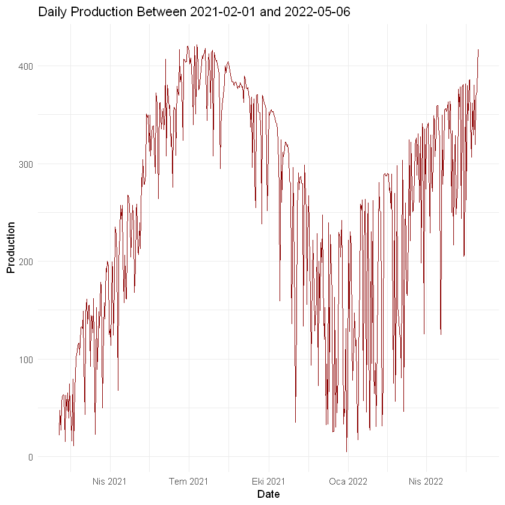

```r
ggplot(new_prod,aes(x=date,y=x)) +geom_line(color = 'darkred') +theme_minimal() + labs(x = 'Date', y = 'Production',title = 'Daily Production Between 2021-02-01 and 2022-05-06')
```

```r
kpss = ur.kpss(new_prod$x)
summary(kpss)
```

```
#######################
# KPSS Unit Root Test #
#######################

Test is of type: mu with 5 lags.

Value of test-statistic is: 0.9874

Critical value for a significance level of:
                10pct  5pct 2.5pct  1pct
critical values 0.347 0.463  0.574 0.739
```

This plot tells us many things. First of all, our data is not stationary. Its mean and variance changes over the time. It makes difficult to model and analyse the behaviour of the given data. Therefore, it should first be made stationary by differencing. Additionally, there is a sign of trend and seasonality. In summer months, production volume increases and in the others production volume decreases. Because of this phenomenon, month variables are included in the models. Additionaly, to reveal the effect of trend moving average values with m=2 also included.

Before starting with modeling part data is differenced and made stationary.

```r
new_prod = data.table(new_prod)
new_prod[,differ:=x-shift(x,1)]
kpss = ur.kpss(new_prod$differ)
summary(kpss)
```

```
#######################
# KPSS Unit Root Test #
#######################

Test is of type: mu with 5 lags.

Value of test-statistic is: 0.0426

Critical value for a significance level of:
                10pct  5pct 2.5pct  1pct
critical values 0.347 0.463  0.574 0.739
```

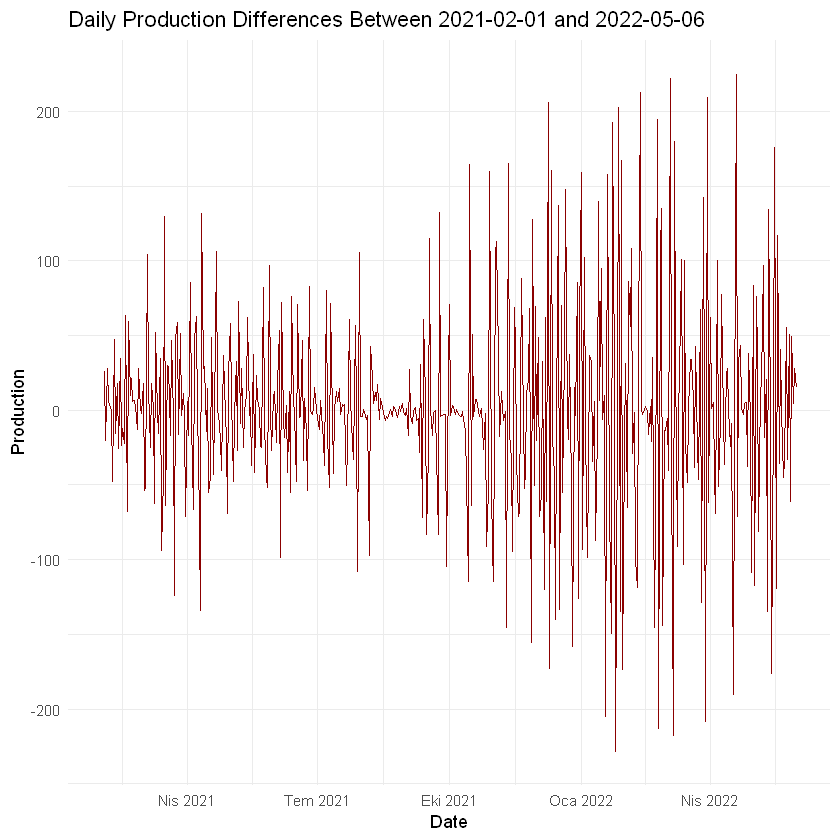

```r
ggplot(new_prod,aes(x=date,y=differ)) +geom_line(color = 'darkred') +theme_minimal() + labs(x = 'Date', y = 'Production',title = 'Daily Production Differences Between 2021-02-01 and 2022-05-06')
```

KPSS unit test and plot tells us that our data is now stationary. It shows us that in the modelling part we should use not the production volumes but the differences of the production volumes.

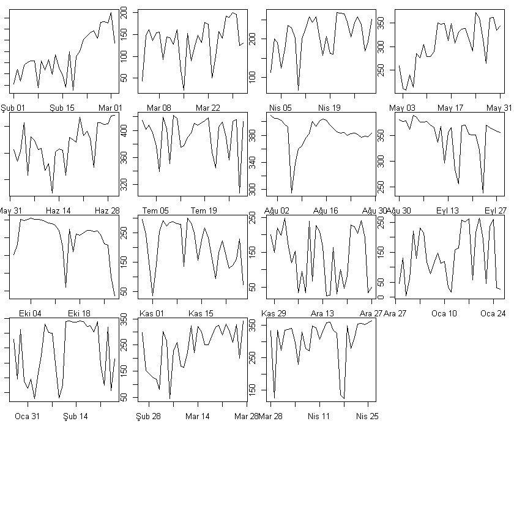

```r
par(mar=c(1,1,1,1))
par(mfrow = c(5,4))
plot(new_prod$date[1:30],new_prod$x[1:30],type = 'l')
plot(new_prod$date[31:60],new_prod$x[31:60],type = 'l')
plot(new_prod$date[61:90],new_prod$x[61:90],type = 'l')
plot(new_prod$date[91:120],new_prod$x[91:120],type = 'l')
plot(new_prod$date[121:150],new_prod$x[121:150],type = 'l')
plot(new_prod$date[151:180],new_prod$x[151:180],type = 'l')
plot(new_prod$date[181:210],new_prod$x[181:210],type = 'l')
plot(new_prod$date[211:240],new_prod$x[211:240],type = 'l')
plot(new_prod$date[241:270],new_prod$x[241:270],type = 'l')
plot(new_prod$date[271:300],new_prod$x[271:300],type = 'l')
plot(new_prod$date[301:330],new_prod$x[301:330],type = 'l')
plot(new_prod$date[331:360],new_prod$x[331:360],type = 'l')
plot(new_prod$date[361:390],new_prod$x[361:390],type = 'l')
plot(new_prod$date[391:420],new_prod$x[391:420],type = 'l')
plot(new_prod$date[421:450],new_prod$x[421:450],type = 'l')
```

When the monthly plots are shown it is clear that summer periods behave similar to each other compared to others. In this periods, volumes are much higher. Therefore, month variable shows its importance.

## Related Literature

For this project, course notes are mainly used. Addditionaly, the online [text book](https://otexts.com/fpp2/) is used to understand some basics and concept and apply them. Additionally, in this project temperature values are adjusted in some manner. It is known that increasing temparature effects the solar power energy production in positive manner but after some point it decreases the efficiency and amount of energy that is produced. Boston Solar Company publishes an article in their business website. In this article it is said that until 25 degree of celcius increasing temparature effects solar plants in positive manner and after 25 degree of celcius this affect turns to negative. In this project a similar manner is applied. In a data driven manner it is seen that beyond some threshold value total energy produced decreases even the temperature increases. Here, this threshold value is determined and temperature values are swapt with dummy variables. This threshold value is determined by data driven approach and it is 280. Temparatures below 280 is 1 indicates positive impact and temperatures beyond 280 is 0 indicating negative impact.

## Approach

Before starting modelling, data is adjusted in some manner. Firstly whole data is turned into wide format.

```r
weather_wide = dcast(weather,date+hour ~ variable +lat + lon , value.var = 'value')
weather_wide$date = ymd(weather_wide$date)
head(weather_wide)

str(weather_wide)
```

| date | hour | CLOUD_LOW_LAYER_36.25_33 | CLOUD_LOW_LAYER_36.25_33.25 | CLOUD_LOW_LAYER_36.25_33.5 | CLOUD_LOW_LAYER_36.5_33 | CLOUD_LOW_LAYER_36.5_33.25 | CLOUD_LOW_LAYER_36.5_33.5 | CLOUD_LOW_LAYER_36.75_33 | CLOUD_LOW_LAYER_36.75_33.25 | ... | REL_HUMIDITY_36.75_33.5 | TEMP_36.25_33 | TEMP_36.25_33.25 | TEMP_36.25_33.5 | TEMP_36.5_33 | TEMP_36.5_33.25 | TEMP_36.5_33.5 | TEMP_36.75_33 | TEMP_36.75_33.25 | TEMP_36.75_33.5 |
| --- | --- | --- | --- | --- | --- | --- | --- | --- | --- | --- | --- | --- | --- | --- | --- | --- | --- | --- | --- | --- |
| 2021-02-01 | 0 | 45 | 31 | 3 | 53 | 10 | 0 | 92 | 26 | ... | 86.3 | 278.620 | 279.080 | 280.130 | 276.110 | 277.770 | 280.650 | 274.830 | 278.170 | 275.730 |
| 2021-02-01 | 1 | 44 | 26 | 19 | 64 | 21 | 0 | 93 | 31 | ... | 84.5 | 277.950 | 278.950 | 281.050 | 276.130 | 277.640 | 280.380 | 274.710 | 278.250 | 275.540 |
| 2021-02-01 | 2 | 37 | 35 | 35 | 60 | 19 | 0 | 92 | 35 | ... | 83.2 | 277.368 | 280.028 | 281.858 | 274.988 | 276.928 | 280.148 | 274.638 | 278.268 | 275.448 |
| 2021-02-01 | 3 | 43 | 45 | 46 | 51 | 24 | 8 | 91 | 36 | ... | 82.8 | 278.405 | 280.555 | 281.695 | 274.565 | 277.075 | 280.405 | 274.535 | 278.015 | 275.685 |
| 2021-02-01 | 4 | 72 | 95 | 46 | 16 | 57 | 1 | 86 | 40 | ... | 83.9 | 278.512 | 280.742 | 280.662 | 274.822 | 277.292 | 280.082 | 274.362 | 277.902 | 275.592 |
| 2021-02-01 | 5 | 69 | 95 | 31 | 24 | 68 | 2 | 86 | 56 | ... | 85.0 | 278.064 | 280.494 | 280.294 | 275.064 | 277.504 | 279.474 | 274.064 | 278.194 | 275.714 |

```
'data.frame':	11808 obs. of  38 variables:
 $ date                       : Date, format: "2021-02-01" "2021-02-01" ...
 $ hour                       : int  0 1 2 3 4 5 6 7 8 9 ...
 $ CLOUD_LOW_LAYER_36.25_33   : num  45 44 37 43 72 69 75 79 83 86 ...
 $ CLOUD_LOW_LAYER_36.25_33.25: num  31 26 35 45 95 95 96 97 97 97 ...
 $ CLOUD_LOW_LAYER_36.25_33.5 : num  3 19 35 46 46 31 53 65 60 67 ...
 $ CLOUD_LOW_LAYER_36.5_33    : num  53 64 60 51 16 24 21 16 13 20 ...
 $ CLOUD_LOW_LAYER_36.5_33.25 : num  10 21 19 24 57 68 63 72 78 78 ...
 $ CLOUD_LOW_LAYER_36.5_33.5  : num  0 0 0 8 1 2 14 36 46 43 ...
 $ CLOUD_LOW_LAYER_36.75_33   : num  92 93 92 91 86 86 86 87 87 87 ...
 $ CLOUD_LOW_LAYER_36.75_33.25: num  26 31 35 36 40 56 64 69 75 78 ...
 $ CLOUD_LOW_LAYER_36.75_33.5 : num  0 0 1 9 36 50 63 72 77 77 ...
 $ DSWRF_36.25_33             : num  0 0 0 0 0 0 0 0 0 3 ...
 $ DSWRF_36.25_33.25          : num  0 0 0 0 0 0 0 0 0 2 ...
 $ DSWRF_36.25_33.5           : num  0 0 0 0 0 0 0 0 0 3 ...
```

[output cut: 24 more lines]

In this data table some values are missing (NA's) and corresponding production volumes are not given because they were dates far beyond the corresponding date (d) and forecasted day (d+1). Therefore, these extra dates and missing values are determined and dropped from the data.

```r
unq_dates_weather = unique(weather_wide$date)
unq_dates_prod = unique(new_prod$date)
remove = as.Date(intersect(unq_dates_weather,unq_dates_prod))

diff_dates= unq_dates_weather[! unq_dates_weather %in% remove]

diff_dates

index_list = c()
for(i in 1:length(diff_dates)){
    index_list = append(index_list,c(which(weather_wide$date == diff_dates[i])))
}

weather_wide = weather_wide[-index_list,]
```

1. 2022-06-01

2. 2022-06-02

3. 2022-06-03

4. 2022-06-04

5. 2022-06-05

6. 2022-06-06

7. 2022-06-07

After this adjusting, productions in the corresponding dates are included as a column to the data table.

```r
weather_wide$production = production$production
head(weather_wide)
```

| date | hour | CLOUD_LOW_LAYER_36.25_33 | CLOUD_LOW_LAYER_36.25_33.25 | CLOUD_LOW_LAYER_36.25_33.5 | CLOUD_LOW_LAYER_36.5_33 | CLOUD_LOW_LAYER_36.5_33.25 | CLOUD_LOW_LAYER_36.5_33.5 | CLOUD_LOW_LAYER_36.75_33 | CLOUD_LOW_LAYER_36.75_33.25 | ... | TEMP_36.25_33 | TEMP_36.25_33.25 | TEMP_36.25_33.5 | TEMP_36.5_33 | TEMP_36.5_33.25 | TEMP_36.5_33.5 | TEMP_36.75_33 | TEMP_36.75_33.25 | TEMP_36.75_33.5 | production |
| --- | --- | --- | --- | --- | --- | --- | --- | --- | --- | --- | --- | --- | --- | --- | --- | --- | --- | --- | --- | --- |
| 2021-02-01 | 0 | 45 | 31 | 3 | 53 | 10 | 0 | 92 | 26 | ... | 278.620 | 279.080 | 280.130 | 276.110 | 277.770 | 280.650 | 274.830 | 278.170 | 275.730 | 0 |
| 2021-02-01 | 1 | 44 | 26 | 19 | 64 | 21 | 0 | 93 | 31 | ... | 277.950 | 278.950 | 281.050 | 276.130 | 277.640 | 280.380 | 274.710 | 278.250 | 275.540 | 0 |
| 2021-02-01 | 2 | 37 | 35 | 35 | 60 | 19 | 0 | 92 | 35 | ... | 277.368 | 280.028 | 281.858 | 274.988 | 276.928 | 280.148 | 274.638 | 278.268 | 275.448 | 0 |
| 2021-02-01 | 3 | 43 | 45 | 46 | 51 | 24 | 8 | 91 | 36 | ... | 278.405 | 280.555 | 281.695 | 274.565 | 277.075 | 280.405 | 274.535 | 278.015 | 275.685 | 0 |
| 2021-02-01 | 4 | 72 | 95 | 46 | 16 | 57 | 1 | 86 | 40 | ... | 278.512 | 280.742 | 280.662 | 274.822 | 277.292 | 280.082 | 274.362 | 277.902 | 275.592 | 0 |
| 2021-02-01 | 5 | 69 | 95 | 31 | 24 | 68 | 2 | 86 | 56 | ... | 278.064 | 280.494 | 280.294 | 275.064 | 277.504 | 279.474 | 274.064 | 278.194 | 275.714 | 0 |

After this point, two new approach is showed in this project. One of them is the productions with zeros. In some hours, electric production is zero because it is night. Here, all zero values are not dropped from the data. A different approach is introduced. Here, the daylight saving policy, that is not used anymore, of Turkey in summer is used. According to this policy in summer peroids clocks were adjusted by one hour in every year. This period was from beggining of April to the end of the September. By this policy, daylight hours in summer and winter periods are determined and dropped from the data to be more consistent.

```r
weather_wide_adj = weather_wide[-c(which(month(weather_wide$date) > 3 & month(weather_wide$date) < 10 & weather_wide$hour < 6)),]
weather_wide_adj = weather_wide_adj[-c(which(month(weather_wide_adj$date) > 3 & month(weather_wide_adj$date) < 10 & weather_wide_adj$hour > 19)),]
weather_wide_adj = weather_wide_adj[-c(which(month(weather_wide_adj$date) < 4  & weather_wide_adj$hour > 17)),]
weather_wide_adj = weather_wide_adj[-c(which(month(weather_wide_adj$date) < 4  & weather_wide_adj$hour < 8)),]
weather_wide_adj = weather_wide_adj[-c(which(month(weather_wide_adj$date) > 9  & weather_wide_adj$hour > 17)),]
weather_wide_adj = weather_wide_adj[-c(which(month(weather_wide_adj$date) > 9  & weather_wide_adj$hour <8)),]



head(weather_wide_adj)
```

|  | date | hour | CLOUD_LOW_LAYER_36.25_33 | CLOUD_LOW_LAYER_36.25_33.25 | CLOUD_LOW_LAYER_36.25_33.5 | CLOUD_LOW_LAYER_36.5_33 | CLOUD_LOW_LAYER_36.5_33.25 | CLOUD_LOW_LAYER_36.5_33.5 | CLOUD_LOW_LAYER_36.75_33 | CLOUD_LOW_LAYER_36.75_33.25 | ... | TEMP_36.25_33 | TEMP_36.25_33.25 | TEMP_36.25_33.5 | TEMP_36.5_33 | TEMP_36.5_33.25 | TEMP_36.5_33.5 | TEMP_36.75_33 | TEMP_36.75_33.25 | TEMP_36.75_33.5 | production |
| --- | --- | --- | --- | --- | --- | --- | --- | --- | --- | --- | --- | --- | --- | --- | --- | --- | --- | --- | --- | --- | --- |
| 9 | 2021-02-01 | 8 | 83 | 97 | 60 | 13 | 78 | 46 | 87 | 75 | ... | 279.296 | 280.806 | 280.616 | 274.506 | 278.626 | 280.996 | 274.166 | 278.676 | 276.626 | 0.189 |
| 10 | 2021-02-01 | 9 | 86 | 97 | 67 | 20 | 78 | 43 | 87 | 78 | ... | 280.070 | 281.090 | 281.930 | 277.250 | 279.430 | 282.220 | 274.580 | 279.150 | 277.820 | 1.350 |
| 11 | 2021-02-01 | 10 | 100 | 100 | 60 | 79 | 95 | 7 | 82 | 68 | ... | 280.478 | 281.468 | 283.518 | 278.748 | 280.378 | 284.028 | 275.548 | 280.148 | 279.178 | 1.730 |
| 12 | 2021-02-01 | 11 | 100 | 100 | 59 | 71 | 96 | 8 | 84 | 75 | ... | 280.869 | 281.759 | 284.099 | 279.799 | 281.239 | 285.209 | 275.989 | 280.929 | 279.799 | 2.730 |
| 13 | 2021-02-01 | 12 | 98 | 100 | 71 | 65 | 98 | 10 | 86 | 78 | ... | 281.540 | 281.900 | 284.090 | 280.340 | 281.850 | 285.850 | 276.440 | 281.210 | 280.280 | 1.950 |
| 14 | 2021-02-01 | 13 | 97 | 100 | 69 | 73 | 98 | 11 | 88 | 82 | ... | 281.768 | 282.078 | 284.658 | 280.298 | 281.858 | 286.528 | 276.698 | 281.408 | 280.538 | 1.350 |

Additionally, decision variables are also adjusted. It is thought that because facilities are in the some region, weather conditions do not change significantly from one location to the other. Therefore in the models weighted average of the weather conditions are used for all days and hours.

```r
mean_rel = NULL
mean_temp = NULL
mean_cloud_low = NULL
mean_DSWR = NULL
for(i in 1:length(weather_wide_adj$date)){
    mean_DSWR[i] = weighted.mean(weather_wide_adj[i,12:20],rep(1/9,9))
    mean_cloud_low[i] = weighted.mean(weather_wide_adj[i,3:11],rep(1/9,9))
    mean_temp[i] = weighted.mean(weather_wide_adj[i,30:38],rep(1/9,9))
    mean_rel[i] = weighted.mean(weather_wide_adj[i,21:29],rep(1/9,9))

}
```

```r
model_data = data.frame('date' = weather_wide_adj$date, 'hour' = weather_wide_adj$hour, mean_cloud_low,mean_DSWR,mean_rel,mean_temp,'production'=weather_wide_adj$production)

model_data
```

| date | hour | mean_cloud_low | mean_DSWR | mean_rel | mean_temp | production |
| --- | --- | --- | --- | --- | --- | --- |
| 2021-02-01 | 8 | 68.4444444 | 0.000000 | 86.85556 | 278.2571 | 0.189 |
| 2021-02-01 | 9 | 70.3333333 | 6.444444 | 85.97778 | 279.2822 | 1.350 |
| 2021-02-01 | 10 | 67.3333333 | 147.777778 | 81.52222 | 280.3880 | 1.730 |
| 2021-02-01 | 11 | 68.6666667 | 203.333333 | 79.65556 | 281.0768 | 2.730 |
| 2021-02-01 | 12 | 71.1111111 | 243.333333 | 78.55556 | 281.5000 | 1.950 |
| 2021-02-01 | 13 | 74.0000000 | 262.222222 | 77.53333 | 281.7591 | 1.350 |
| 2021-02-01 | 14 | 74.7777778 | 287.777778 | 74.94444 | 282.1253 | 2.040 |
| 2021-02-01 | 15 | 76.6666667 | 296.666667 | 72.57778 | 282.2374 | 3.150 |
| 2021-02-01 | 16 | 72.7777778 | 264.444444 | 72.85556 | 282.1279 | 5.830 |
| 2021-02-01 | 17 | 59.7777778 | 233.333333 | 73.53333 | 281.7987 | 1.350 |
| 2021-02-02 | 8 | 0.0000000 | 0.000000 | 68.12222 | 277.1861 | 1.160 |
| 2021-02-02 | 9 | 0.0000000 | 10.000000 | 65.34444 | 279.2800 | 5.040 |
| 2021-02-02 | 10 | 0.0000000 | 188.888889 | 59.01111 | 281.4968 | 6.770 |
| 2021-02-02 | 11 | 0.0000000 | 257.777778 | 56.11111 | 282.6386 | 7.110 |
| 2021-02-02 | 12 | 0.0000000 | 321.111111 | 54.48889 | 283.6012 | 7.870 |
| 2021-02-02 | 13 | 0.0000000 | 364.444444 | 53.74444 | 284.3488 | 6.450 |
| 2021-02-02 | 14 | 0.0000000 | 390.000000 | 53.84444 | 284.8672 | 5.440 |
| 2021-02-02 | 15 | 0.0000000 | 395.555556 | 54.82222 | 285.0631 | 4.880 |
| 2021-02-02 | 16 | 0.0000000 | 298.888889 | 56.10000 | 285.1638 | 2.550 |
| 2021-02-02 | 17 | 0.0000000 | 240.000000 | 62.00000 | 284.6354 | 0.500 |
| 2021-02-03 | 8 | 27.0000000 | 0.000000 | 65.38889 | 279.8827 | 0.250 |
| 2021-02-03 | 9 | 27.8888889 | 10.000000 | 64.38889 | 281.8851 | 0.560 |
| 2021-02-03 | 10 | 24.7777778 | 198.888889 | 55.35556 | 284.1767 | 0.910 |
| 2021-02-03 | 11 | 18.2222222 | 295.555556 | 52.41111 | 285.1271 | 1.380 |
| 2021-02-03 | 12 | 23.0000000 | 360.000000 | 51.71111 | 285.7144 | 2.920 |
| 2021-02-03 | 13 | 25.3333333 | 401.111111 | 51.70000 | 286.1041 | 4.590 |
| 2021-02-03 | 14 | 23.3333333 | 421.111111 | 51.96667 | 286.3777 | 6.830 |
| 2021-02-03 | 15 | 19.3333333 | 430.000000 | 52.57778 | 286.5562 | 5.480 |
| 2021-02-03 | 16 | 0.7777778 | 374.444444 | 52.18889 | 286.7054 | 3.710 |
| 2021-02-03 | 17 | 0.3333333 | 302.222222 | 56.00000 | 286.0239 | 0.660 |
| ... | ... | ... | ... | ... | ... | ... |
| 2022-05-29 | 18 | 0.5555556 | 547.082222 | 29.08889 | 300.3162 | 9.50 |
| 2022-05-29 | 19 | 0.5666667 | 457.420000 | 32.68889 | 299.1576 | 1.34 |
| 2022-05-30 | 6 | 0.0000000 | 1.988889 | 44.70000 | 293.1711 | 6.90 |
| 2022-05-30 | 7 | 0.0000000 | 30.620444 | 37.30000 | 296.6297 | 24.70 |
| 2022-05-30 | 8 | 0.0000000 | 87.224889 | 31.57778 | 298.2699 | 35.00 |
| 2022-05-30 | 9 | 0.0000000 | 159.173333 | 28.97778 | 299.6263 | 34.96 |
| 2022-05-30 | 10 | 0.0000000 | 705.471111 | 26.56667 | 300.8334 | 36.60 |
| 2022-05-30 | 11 | 0.0000000 | 780.404444 | 25.07778 | 301.8413 | 38.49 |
| 2022-05-30 | 12 | 0.0000000 | 833.457778 | 23.87778 | 302.6429 | 38.12 |
| 2022-05-30 | 13 | 0.1000000 | 871.091111 | 22.83333 | 303.2560 | 37.86 |
| 2022-05-30 | 14 | 0.1222222 | 893.597778 | 22.08889 | 303.6222 | 37.95 |
| 2022-05-30 | 15 | 0.1000000 | 895.820444 | 21.76667 | 303.6909 | 37.92 |
| 2022-05-30 | 16 | 0.0000000 | 748.066667 | 22.34444 | 303.2444 | 37.22 |
| 2022-05-30 | 17 | 0.2777778 | 644.982222 | 22.62222 | 302.5473 | 24.94 |
| 2022-05-30 | 18 | 0.2111111 | 567.266667 | 22.63333 | 301.8931 | 10.01 |
| 2022-05-30 | 19 | 0.1555556 | 478.202222 | 26.07778 | 300.6251 | 0.00 |
| 2022-05-31 | 6 | 0.0000000 | 2.100000 | 33.84444 | 292.8922 | 6.93 |
| 2022-05-31 | 7 | 0.0000000 | 31.751111 | 29.96667 | 296.4311 | 25.60 |
| 2022-05-31 | 8 | 0.0000000 | 89.692444 | 25.26667 | 297.9716 | 39.00 |
| 2022-05-31 | 9 | 0.0000000 | 162.901333 | 24.57778 | 299.1140 | 39.27 |
| 2022-05-31 | 10 | 0.0000000 | 715.282222 | 24.05556 | 300.2051 | 38.84 |
| 2022-05-31 | 11 | 0.0000000 | 790.628889 | 22.75556 | 301.2332 | 38.58 |
| 2022-05-31 | 12 | 0.0000000 | 849.444444 | 21.41111 | 302.0787 | 37.96 |
| 2022-05-31 | 13 | 0.0000000 | 889.935556 | 20.44444 | 302.6443 | 37.96 |
| 2022-05-31 | 14 | 0.0000000 | 911.126667 | 19.70000 | 302.9863 | 37.86 |
| 2022-05-31 | 15 | 0.0000000 | 912.910222 | 19.24444 | 302.9240 | 37.93 |
| 2022-05-31 | 16 | 0.0000000 | 795.477778 | 18.81111 | 302.4527 | 37.64 |
| 2022-05-31 | 17 | 0.0000000 | 710.415556 | 19.23333 | 301.8398 | 26.77 |
| 2022-05-31 | 18 | 0.0000000 | 615.620000 | 20.63333 | 300.8556 | 10.33 |
| 2022-05-31 | 19 | 0.0000000 | 516.171111 | 25.33333 | 299.4112 | 1.48 |

New data table is assigned to variable model_data to be more flexible for any possible changes during the evaluation. As discussed before, differencing columns will be added to model_data to make our data stationary.

```r
model_data = data.table(model_data)
model_data[,differ:= production-shift(production,1)]
```

```r
kpss = ur.kpss(model_data$differ)
summary(kpss)
```

```
#######################
# KPSS Unit Root Test #
#######################

Test is of type: mu with 11 lags.

Value of test-statistic is: 0.0058

Critical value for a significance level of:
                10pct  5pct 2.5pct  1pct
critical values 0.347 0.463  0.574 0.739
```

Finally, trend values and dummy variable that indicates month of the date are added to model_data and first model is constructed.

```r
model_data$which_month = as.factor(month(model_data$date))

model_data$hour = as.factor(model_data$hour)
model_data$trend = ma(model_data$production,2)

str(model_data)
```

```
Classes 'data.table' and 'data.frame':	5826 obs. of  10 variables:
 $ date          : Date, format: "2021-02-01" "2021-02-01" ...
 $ hour          : Factor w/ 14 levels "6","7","8","9",..: 3 4 5 6 7 8 9 10 11 12 ...
 $ mean_cloud_low: num  68.4 70.3 67.3 68.7 71.1 ...
 $ mean_DSWR     : num  0 6.44 147.78 203.33 243.33 ...
 $ mean_rel      : num  86.9 86 81.5 79.7 78.6 ...
 $ mean_temp     : num  278 279 280 281 282 ...
 $ production    : num  0.189 1.35 1.73 2.73 1.95 1.35 2.04 3.15 5.83 1.35 ...
 $ differ        : num  NA 1.16 0.38 1 -0.78 ...
 $ which_month   : Factor w/ 12 levels "1","2","3","4",..: 2 2 2 2 2 2 2 2 2 2 ...
 $ trend         : Time-Series  from 1 to 5826: NA 1.15 1.88 2.29 2 ...
 - attr(*, ".internal.selfref")=<externalptr>
```

```
Call:
lm(formula = differ ~ . - date - production, data = model_data)

Residuals:
     Min       1Q   Median       3Q      Max
-31.5881  -2.4579   0.1185   2.4163  26.2553

Coefficients:
                 Estimate Std. Error t value Pr(>|t|)
(Intercept)     0.6453465  5.5568073   0.116 0.907549
hour7          10.6289985  0.4765889  22.302  < 2e-16 ***
hour8           6.5106788  0.4781888  13.615  < 2e-16 ***
hour9           1.5755641  0.5214005   3.022 0.002524 **
hour10          0.6749493  0.6886296   0.980 0.327061
hour11         -0.0685472  0.7351486  -0.093 0.925714
hour12          0.2161374  0.7730623   0.280 0.779805
hour13          0.4264629  0.7993096   0.534 0.593681
hour14         -0.0050545  0.8106024  -0.006 0.995025
hour15         -0.3102947  0.8057898  -0.385 0.700191
hour16         -3.1686518  0.7276549  -4.355 1.36e-05 ***
hour17         -7.3889535  0.6657266 -11.099  < 2e-16 ***
hour18         -8.6644440  0.6435607 -13.463  < 2e-16 ***
hour19         -2.3485749  0.5918234  -3.968 7.32e-05 ***
mean_cloud_low -0.0017194  0.0046636  -0.369 0.712384
mean_DSWR      -0.0092829  0.0008002 -11.601  < 2e-16 ***
mean_rel        0.0143672  0.0076357   1.882 0.059944 .
mean_temp      -0.0080785  0.0198935  -0.406 0.684695
which_month2    1.4821650  0.3741585   3.961 7.54e-05 ***
which_month3    1.6044876  0.3914898   4.098 4.22e-05 ***
which_month4    2.2019724  0.4874179   4.518 6.38e-06 ***
which_month5    2.1457099  0.5632386   3.810 0.000141 ***
which_month6    1.6897128  0.6295021   2.684 0.007291 **
which_month7    1.3635219  0.6889998   1.979 0.047865 *
which_month8    1.2416603  0.6752604   1.839 0.065998 .
which_month9    0.7956081  0.5828964   1.365 0.172331
which_month10  -0.0076457  0.5263142  -0.015 0.988410
which_month11   0.0562488  0.4640159   0.121 0.903520
which_month12   0.3739151  0.4171988   0.896 0.370156
trend           0.1815795  0.0102695  17.681  < 2e-16 ***
---
Signif. codes:  0 '***' 0.001 '**' 0.01 '*' 0.05 '.' 0.1 ' ' 1

Residual standard error: 5.093 on 5794 degrees of freedom
  (2 observations deleted due to missingness)
Multiple R-squared:  0.596,	Adjusted R-squared:  0.594
F-statistic: 294.8 on 29 and 5794 DF,  p-value: < 2.2e-16
```

```
	Breusch-Godfrey test for serial correlation of order up to 33

data:  Residuals
LM test = 1105.5, df = 33, p-value < 2.2e-16
```

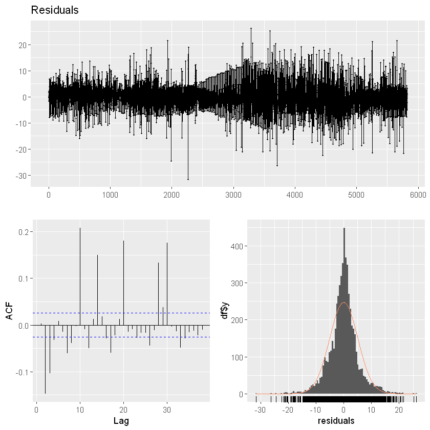

```r
model = lm(differ~.-date-production,model_data)
summary(model)
checkresiduals(model)
```

This model shows us that adjusted R^2 value is very low. This indicates that our model is not sufficient enough to explain behaviour of our data. Additionally, our residuals are highly correlated and it does not hold the normality assumptions. To avoid these problems two type of new variables are introduced. Firstly, an autoregressive part is introduced.After some trials that are not shown in here but shown in the code file, it is thought that an autoregressive part with degree of 14 can be usefull because after eliminating zeros a day contains almost 14 hour in the dataset and values during a whole day can be effective while predicting the production amount of corresponding day. Addition to that outliers are determined and their effects are indicated with dummy variables. These dummy variables take values 0 or 1. If a datapoint is outlier then automatically it becomes 1 and otherwise it is zero. Therefore, these variables are included in the model_data and in the whole models.

```r
model_data$lag_1 = c(NaN,model_data$differ[1:(length(model_data$date)-1)])
```

```
Call:
lm(formula = differ ~ . - date - production, data = model_data)

Residuals:
     Min       1Q   Median       3Q      Max
-31.5259  -2.4677   0.1149   2.4294  26.2714

Coefficients:
                 Estimate Std. Error t value Pr(>|t|)
(Intercept)     0.4579840  5.5682791   0.082 0.934452
hour7          10.6500263  0.4785742  22.254  < 2e-16 ***
hour8           6.5496469  0.4853676  13.494  < 2e-16 ***
hour9           1.6539281  0.5448134   3.036 0.002410 **
hour10          0.7750294  0.7219510   1.074 0.283082
hour11          0.0150994  0.7580211   0.020 0.984108
hour12          0.2995941  0.7950945   0.377 0.706334
hour13          0.5147084  0.8231700   0.625 0.531815
hour14          0.0866993  0.8360270   0.104 0.917408
hour15         -0.2185020  0.8314674  -0.263 0.792721
hour16         -3.0881742  0.7496262  -4.120 3.85e-05 ***
hour17         -7.3218639  0.6827968 -10.723  < 2e-16 ***
hour18         -8.6269190  0.6498528 -13.275  < 2e-16 ***
hour19         -2.3221014  0.5955183  -3.899 9.76e-05 ***
mean_cloud_low -0.0017726  0.0046710  -0.379 0.704339
mean_DSWR      -0.0094301  0.0008628 -10.930  < 2e-16 ***
mean_rel        0.0143063  0.0076385   1.873 0.061129 .
mean_temp      -0.0076742  0.0199091  -0.385 0.699909
which_month2    1.5018131  0.3759915   3.994 6.57e-05 ***
which_month3    1.6258943  0.3943682   4.123 3.80e-05 ***
which_month4    2.2397673  0.4944163   4.530 6.01e-06 ***
which_month5    2.1821435  0.5691571   3.834 0.000127 ***
which_month6    1.7205180  0.6334932   2.716 0.006629 **
which_month7    1.3858169  0.6911491   2.005 0.045000 *
which_month8    1.2610945  0.6769627   1.863 0.062531 .
which_month9    0.8113095  0.5841358   1.389 0.164915
which_month10  -0.0175401  0.5267456  -0.033 0.973437
which_month11   0.0480195  0.4643907   0.103 0.917647
which_month12   0.3742657  0.4172604   0.897 0.369778
trend           0.1837391  0.0112308  16.360  < 2e-16 ***
lag_1          -0.0061515  0.0126685  -0.486 0.627287
---
Signif. codes:  0 '***' 0.001 '**' 0.01 '*' 0.05 '.' 0.1 ' ' 1

Residual standard error: 5.094 on 5792 degrees of freedom
  (3 observations deleted due to missingness)
Multiple R-squared:  0.596,	Adjusted R-squared:  0.594
F-statistic: 284.9 on 30 and 5792 DF,  p-value: < 2.2e-16
```

```
	Breusch-Godfrey test for serial correlation of order up to 34

data:  Residuals
LM test = 1114.9, df = 34, p-value < 2.2e-16
```

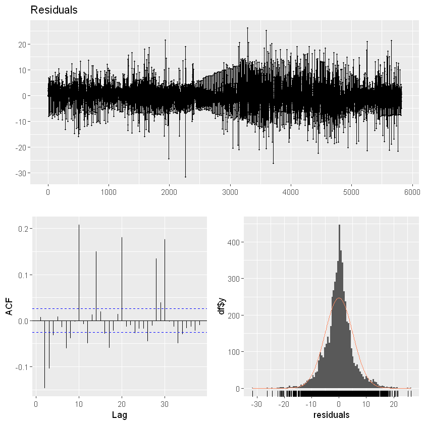

```r
model = lm(differ~.-date-production,model_data)
summary(model)
checkresiduals(model)
```

```r
model_data$residuals = c(rep(NaN,2),model$residuals,NaN)
model_data$up_quan = rep(0,length(model_data$differ))
model_data$down_quan = rep(0,length(model_data$differ))
model_data[which(model_data$residual > quantile(model$residual,0.95)),length(model_data)-1] = 1
model_data[which(model_data$residual < quantile(model$residual,0.05)),length(model_data)] = 1
head(model_data)
```

| date | hour | mean_cloud_low | mean_DSWR | mean_rel | mean_temp | production | differ | which_month | trend | lag_1 | residuals | up_quan | down_quan |
| --- | --- | --- | --- | --- | --- | --- | --- | --- | --- | --- | --- | --- | --- |
| 2021-02-01 | 8 | 68.44444 | 0.000000 | 86.85556 | 278.2571 | 0.189 | NA | 2 | NA | NaN | NaN | 0 | 0 |
| 2021-02-01 | 9 | 70.33333 | 6.444444 | 85.97778 | 279.2822 | 1.350 | 1.161 | 2 | 1.15475 | NA | NaN | 0 | 0 |
| 2021-02-01 | 10 | 67.33333 | 147.777778 | 81.52222 | 280.3880 | 1.730 | 0.380 | 2 | 1.88500 | 1.161 | -0.19565451 | 0 | 0 |
| 2021-02-01 | 11 | 68.66667 | 203.333333 | 79.65556 | 281.0768 | 2.730 | 1.000 | 2 | 2.28500 | 0.380 | 1.66422191 | 0 | 0 |
| 2021-02-01 | 12 | 71.11111 | 243.333333 | 78.55556 | 281.5000 | 1.950 | -0.780 | 2 | 1.99500 | 1.000 | 0.05734556 | 0 | 0 |
| 2021-02-01 | 13 | 74.00000 | 262.222222 | 77.53333 | 281.7591 | 1.350 | -0.600 | 2 | 1.67250 | -0.780 | 0.27039414 | 0 | 0 |

```r
model_data$lag_2 = c(rep(NaN,2),model_data$differ[1:(length(model_data$date)-2)])
model_data$lag_3 = c(rep(NaN,3),model_data$differ[1:(length(model_data$date)-3)])
model_data$lag_4 = c(rep(NaN,4),model_data$differ[1:(length(model_data$date)-4)])
model_data$lag_5 = c(rep(NaN,5),model_data$differ[1:(length(model_data$date)-5)])
model_data$lag_6 = c(rep(NaN,6),model_data$differ[1:(length(model_data$date)-6)])
model_data$lag_7 = c(rep(NaN,7),model_data$differ[1:(length(model_data$date)-7)])
model_data$lag_8 = c(rep(NaN,8),model_data$differ[1:(length(model_data$date)-8)])
model_data$lag_9 = c(rep(NaN,9),model_data$differ[1:(length(model_data$date)-9)])
model_data$lag_10 = c(rep(NaN,10),model_data$differ[1:(length(model_data$date)-10)])
model_data$lag_11 = c(rep(NaN,11),model_data$differ[1:(length(model_data$date)-11)])
model_data$lag_12 = c(rep(NaN,12),model_data$differ[1:(length(model_data$date)-12)])
model_data$lag_13 = c(rep(NaN,13),model_data$differ[1:(length(model_data$date)-13)])
model_data$lag_14 = c(rep(NaN,14),model_data$differ[1:(length(model_data$date)-14)])
```

```
Call:
lm(formula = differ ~ . - date - residuals - production, data = model_data)

Residuals:
     Min       1Q   Median       3Q      Max
-19.7135  -1.6611   0.0605   1.6949  11.7436

Coefficients:
                 Estimate Std. Error t value Pr(>|t|)
(Intercept)    -1.026e+01  3.271e+00  -3.137 0.001716 **
hour7           9.593e+00  3.123e-01  30.714  < 2e-16 ***
hour8           6.966e+00  3.622e-01  19.234  < 2e-16 ***
hour9           3.379e+00  4.124e-01   8.193 3.11e-16 ***
hour10          6.224e+00  5.067e-01  12.283  < 2e-16 ***
hour11          6.560e+00  5.110e-01  12.838  < 2e-16 ***
hour12          6.371e+00  5.179e-01  12.300  < 2e-16 ***
hour13          5.744e+00  5.336e-01  10.764  < 2e-16 ***
hour14          5.397e+00  5.418e-01   9.961  < 2e-16 ***
hour15          4.780e+00  5.444e-01   8.782  < 2e-16 ***
hour16          2.749e+00  5.072e-01   5.420 6.19e-08 ***
hour17         -2.282e+00  4.649e-01  -4.909 9.41e-07 ***
hour18         -4.440e+00  4.371e-01 -10.159  < 2e-16 ***
hour19          3.133e-01  3.758e-01   0.834 0.404395
mean_cloud_low -7.896e-03  2.740e-03  -2.882 0.003963 **
mean_DSWR      -8.616e-03  5.444e-04 -15.827  < 2e-16 ***
mean_rel        2.665e-02  4.492e-03   5.933 3.14e-09 ***
mean_temp       7.555e-03  1.158e-02   0.653 0.514032
which_month2    1.767e+00  2.191e-01   8.065 8.87e-16 ***
which_month3    1.557e+00  2.318e-01   6.714 2.07e-11 ***
which_month4    2.640e+00  2.932e-01   9.004  < 2e-16 ***
which_month5    2.111e+00  3.365e-01   6.274 3.77e-10 ***
which_month6    1.279e+00  3.742e-01   3.417 0.000637 ***
which_month7    8.345e-01  4.064e-01   2.053 0.040080 *
which_month8    8.135e-01  3.972e-01   2.048 0.040612 *
which_month9    2.286e-01  3.429e-01   0.667 0.505113
which_month10  -1.449e+00  3.103e-01  -4.670 3.08e-06 ***
which_month11  -4.769e-01  2.694e-01  -1.770 0.076815 .
which_month12   3.291e-01  2.416e-01   1.362 0.173301
trend           2.585e-01  7.571e-03  34.145  < 2e-16 ***
lag_1          -1.223e-01  9.876e-03 -12.380  < 2e-16 ***
up_quan         1.012e+01  2.016e-01  50.194  < 2e-16 ***
down_quan      -1.061e+01  1.891e-01 -56.106  < 2e-16 ***
lag_2          -2.925e-01  9.305e-03 -31.431  < 2e-16 ***
lag_3          -2.224e-01  9.441e-03 -23.556  < 2e-16 ***
lag_4          -2.060e-01  9.419e-03 -21.872  < 2e-16 ***
lag_5          -1.511e-01  9.593e-03 -15.748  < 2e-16 ***
lag_6          -1.338e-01  9.135e-03 -14.653  < 2e-16 ***
lag_7          -1.209e-01  8.613e-03 -14.033  < 2e-16 ***
lag_8          -1.060e-01  8.393e-03 -12.626  < 2e-16 ***
lag_9          -9.146e-02  8.088e-03 -11.307  < 2e-16 ***
lag_10         -6.557e-02  7.871e-03  -8.330  < 2e-16 ***
lag_11         -7.518e-02  8.472e-03  -8.873  < 2e-16 ***
lag_12         -8.587e-02  8.448e-03 -10.165  < 2e-16 ***
lag_13         -2.358e-02  8.268e-03  -2.852 0.004360 **
lag_14          2.180e-02  7.862e-03   2.773 0.005573 **
---
Signif. codes:  0 '***' 0.001 '**' 0.01 '*' 0.05 '.' 0.1 ' ' 1

Residual standard error: 2.946 on 5764 degrees of freedom
  (16 observations deleted due to missingness)
Multiple R-squared:  0.8655,	Adjusted R-squared:  0.8644
F-statistic:   824 on 45 and 5764 DF,  p-value: < 2.2e-16
```

```
	Breusch-Godfrey test for serial correlation of order up to 49

data:  Residuals
LM test = 1209.6, df = 49, p-value < 2.2e-16
```

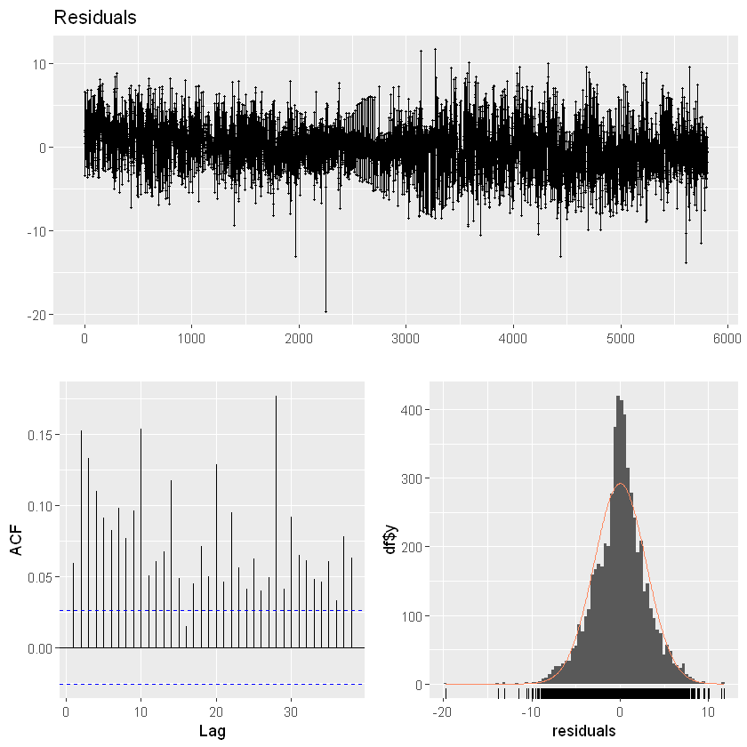

```r
model = lm(differ~.-date-residuals-production,model_data)
summary(model)
checkresiduals(model)
```

Here it can be seen that our new variables are significant and adjusted R^2 of the model jumps from 0.594 to 0.8644. It tells us that our approaches worked well for our model. However, mean_temp is not significant and the normality assumption of the residuals still is not satisfied. Here, the approach explained in the related litarature section is used. To determine the threshold value, monthly average temperature values and producution values are shown.

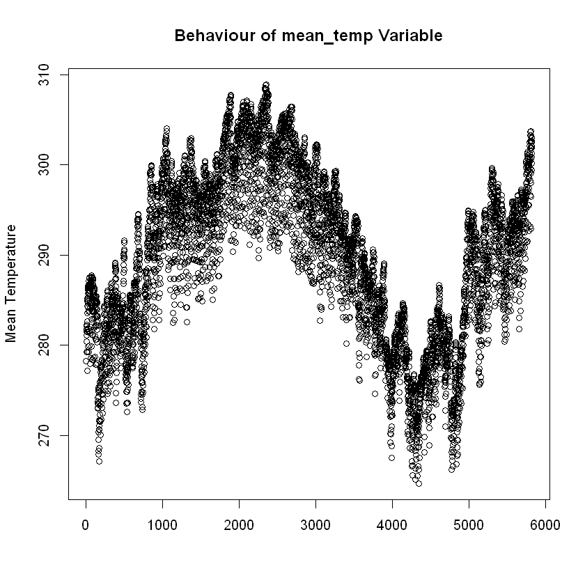

```r
plot(1:length(model_data$mean_temp),model_data$mean_temp,xlab ='',ylab ='Mean Temperature',main = 'Behaviour of mean_temp Variable')
```

```r
new_temp = aggregate(model_data$mean_temp,by =list(date =month(model_data$date) ),FUN = mean)
new_temp
new_prod_hour = aggregate(model_data$production,by =list(date = month(model_data$date)),FUN = mean)
new_prod_hour
```

| date | x |
| --- | --- |
| 1 | 276.0752 |
| 2 | 279.9885 |
| 3 | 279.9339 |
| 4 | 289.3163 |
| 5 | 294.0640 |
| 6 | 296.3712 |
| 7 | 301.2274 |
| 8 | 301.0094 |
| 9 | 295.5934 |
| 10 | 291.9563 |
| 11 | 287.4451 |
| 12 | 280.2478 |

| date | x |
| --- | --- |
| 1 | 15.17230 |
| 2 | 13.38694 |
| 3 | 18.71885 |
| 4 | 18.45971 |
| 5 | 22.64356 |
| 6 | 26.18121 |
| 7 | 28.06392 |
| 8 | 27.32654 |
| 9 | 24.64711 |
| 10 | 29.31887 |
| 11 | 20.24398 |
| 12 | 12.43173 |

Here, it can be seen that there is a huge increase after month 5 and decrease after month 10. These months are actually months that are determined by the Turkish daylight policy approach. Therefore, it can be said that it will be consistent with our assumptions. Related to this months, the threshold value for temperature is 290. Therefore, in the data temperatures higher than 290 are determined as 0 and temperatures lower than 290 are determined as 1. It is done because after some trials, it is found out that our model works well for high temperature and works bad for low temperatures. Therefore, it is done like it is mentioned. Additionaly, when the threshold value is determined as 290, it is seen that mean_temp value does not represent the behaviour good enough. Therefore, threshold value is increased and decreased and the optimal threshold value is found as 280. Therefore, mean_temp values are adjusted by keeping threshold value as 280.

```r
model_data_tr = model_data
```

```r
model_data_tr$mean_temp[which(model_data_tr$mean_temp <= 280)] = 1
model_data_tr$mean_temp[which(model_data_tr$mean_temp > 280)] = 0

model_data_tr$mean_temp = as.factor(model_data_tr$mean_temp)
```

```
Call:
lm(formula = differ ~ . - date - residuals - production, data = model_data_tr)

Residuals:
     Min       1Q   Median       3Q      Max
-19.6419  -1.6674   0.0586   1.6742  11.8010

Coefficients:
                 Estimate Std. Error t value Pr(>|t|)
(Intercept)    -7.740e+00  5.352e-01 -14.463  < 2e-16 ***
hour7           9.580e+00  3.110e-01  30.805  < 2e-16 ***
hour8           6.958e+00  3.586e-01  19.399  < 2e-16 ***
hour9           3.317e+00  4.079e-01   8.131 5.18e-16 ***
hour10          6.073e+00  5.017e-01  12.105  < 2e-16 ***
hour11          6.375e+00  5.048e-01  12.630  < 2e-16 ***
hour12          6.163e+00  5.104e-01  12.075  < 2e-16 ***
hour13          5.517e+00  5.257e-01  10.494  < 2e-16 ***
hour14          5.150e+00  5.344e-01   9.638  < 2e-16 ***
hour15          4.531e+00  5.374e-01   8.430  < 2e-16 ***
hour16          2.516e+00  5.009e-01   5.024 5.22e-07 ***
hour17         -2.475e+00  4.591e-01  -5.391 7.27e-08 ***
hour18         -4.561e+00  4.313e-01 -10.575  < 2e-16 ***
hour19          2.379e-01  3.708e-01   0.642  0.52121
mean_cloud_low -5.247e-03  2.816e-03  -1.863  0.06253 .
mean_DSWR      -8.446e-03  5.452e-04 -15.491  < 2e-16 ***
mean_rel        2.622e-02  4.287e-03   6.116 1.02e-09 ***
mean_temp1     -5.752e-01  1.459e-01  -3.942 8.16e-05 ***
which_month2    1.680e+00  2.185e-01   7.688 1.74e-14 ***
which_month3    1.394e+00  2.342e-01   5.950 2.83e-09 ***
which_month4    2.330e+00  2.816e-01   8.273  < 2e-16 ***
which_month5    1.774e+00  3.038e-01   5.838 5.58e-09 ***
which_month6    9.466e-01  3.268e-01   2.896  0.00379 **
which_month7    5.333e-01  3.296e-01   1.618  0.10570
which_month8    5.211e-01  3.224e-01   1.617  0.10604
which_month9   -8.474e-02  2.977e-01  -0.285  0.77592
which_month10  -1.774e+00  2.928e-01  -6.060 1.45e-09 ***
which_month11  -7.869e-01  2.658e-01  -2.960  0.00309 **
which_month12   2.396e-01  2.400e-01   0.998  0.31828
trend           2.626e-01  7.563e-03  34.721  < 2e-16 ***
lag_1          -1.237e-01  9.866e-03 -12.542  < 2e-16 ***
up_quan         1.012e+01  2.013e-01  50.267  < 2e-16 ***
down_quan      -1.058e+01  1.890e-01 -55.950  < 2e-16 ***
lag_2          -2.927e-01  9.293e-03 -31.502  < 2e-16 ***
lag_3          -2.226e-01  9.428e-03 -23.611  < 2e-16 ***
lag_4          -2.052e-01  9.408e-03 -21.810  < 2e-16 ***
lag_5          -1.503e-01  9.582e-03 -15.689  < 2e-16 ***
lag_6          -1.328e-01  9.126e-03 -14.553  < 2e-16 ***
lag_7          -1.198e-01  8.607e-03 -13.917  < 2e-16 ***
lag_8          -1.049e-01  8.387e-03 -12.502  < 2e-16 ***
lag_9          -9.047e-02  8.081e-03 -11.196  < 2e-16 ***
lag_10         -6.523e-02  7.858e-03  -8.301  < 2e-16 ***
lag_11         -7.508e-02  8.457e-03  -8.878  < 2e-16 ***
lag_12         -8.604e-02  8.429e-03 -10.208  < 2e-16 ***
lag_13         -2.398e-02  8.251e-03  -2.907  0.00367 **
lag_14          2.069e-02  7.848e-03   2.636  0.00842 **
---
Signif. codes:  0 '***' 0.001 '**' 0.01 '*' 0.05 '.' 0.1 ' ' 1

Residual standard error: 2.943 on 5764 degrees of freedom
  (16 observations deleted due to missingness)
Multiple R-squared:  0.8658,	Adjusted R-squared:  0.8648
F-statistic: 826.5 on 45 and 5764 DF,  p-value: < 2.2e-16
```

```
	Breusch-Godfrey test for serial correlation of order up to 49

data:  Residuals
LM test = 1207.5, df = 49, p-value < 2.2e-16
```

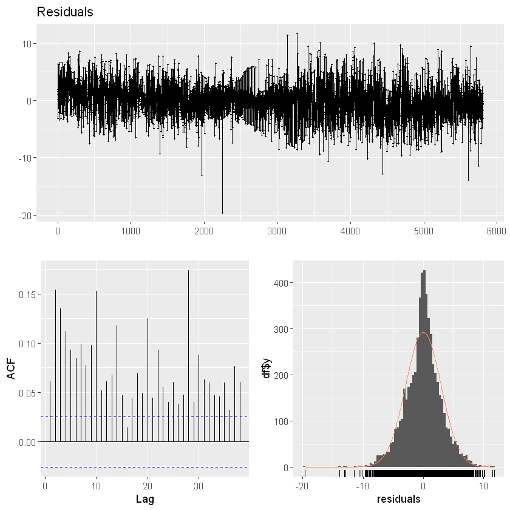

```r
model = lm(differ~.-date-residuals-production,model_data_tr)
summary(model)
checkresiduals(model)
```

## Results

```r
predicted = predict(model,model_data_tr)
model_data_tr$predicted = predicted
model_data_tr$predicted_prod = c(rep(NaN,15),(model_data_tr$production[15:(length(model_data_tr$production)-2)] + model_data_tr$predicted[16:(length(model_data_tr$predicted)-1)]),NaN)
```

```r
ev_model = model_data_tr[-c(which(model_data_tr$date < '2022-03-01'),which(model_data_tr$date >'2022-05-24'))]
```

```r
head(ev_model)
tail(ev_model)
```

| date | hour | mean_cloud_low | mean_DSWR | mean_rel | mean_temp | production | differ | which_month | trend | ... | lag_7 | lag_8 | lag_9 | lag_10 | lag_11 | lag_12 | lag_13 | lag_14 | predicted | predicted_prod |
| --- | --- | --- | --- | --- | --- | --- | --- | --- | --- | --- | --- | --- | --- | --- | --- | --- | --- | --- | --- | --- |
| 2022-03-01 | 8 | 57.16667 | 2.663111 | 83.04444 | 1 | 3.65 | -7.46 | 3 | 8.2550 | ... | 0.50 | 3.51 | 3.87 | -6.30 | -4.22 | -3.03 | 3.09 | 1.95 | -5.2095458 | 5.900454 |
| 2022-03-01 | 9 | 57.51111 | 17.607111 | 77.07778 | 0 | 14.61 | 10.96 | 3 | 13.8850 | ... | 6.17 | 0.50 | 3.51 | 3.87 | -6.30 | -4.22 | -3.03 | 3.09 | 4.5342644 | 8.184264 |
| 2022-03-01 | 10 | 66.11111 | 209.548889 | 74.71111 | 0 | 22.67 | 8.06 | 3 | 21.6575 | ... | -4.56 | 6.17 | 0.50 | 3.51 | 3.87 | -6.30 | -4.22 | -3.03 | 7.0341388 | 21.644139 |
| 2022-03-01 | 11 | 55.16667 | 292.940000 | 72.32222 | 0 | 26.68 | 4.01 | 3 | 21.7375 | ... | -1.87 | -4.56 | 6.17 | 0.50 | 3.51 | 3.87 | -6.30 | -4.22 | 2.5365313 | 25.206531 |
| 2022-03-01 | 12 | 57.98889 | 347.282222 | 69.66667 | 0 | 10.92 | -15.76 | 3 | 15.1375 | ... | -0.18 | -1.87 | -4.56 | 6.17 | 0.50 | 3.51 | 3.87 | -6.30 | -11.7940496 | 14.885950 |
| 2022-03-01 | 13 | 67.47778 | 336.633333 | 69.98889 | 0 | 12.03 | 1.11 | 3 | 13.0050 | ... | -2.34 | -0.18 | -1.87 | -4.56 | 6.17 | 0.50 | 3.51 | 3.87 | -0.5001849 | 10.419815 |

| date | hour | mean_cloud_low | mean_DSWR | mean_rel | mean_temp | production | differ | which_month | trend | ... | lag_7 | lag_8 | lag_9 | lag_10 | lag_11 | lag_12 | lag_13 | lag_14 | predicted | predicted_prod |
| --- | --- | --- | --- | --- | --- | --- | --- | --- | --- | --- | --- | --- | --- | --- | --- | --- | --- | --- | --- | --- |
| 2022-05-24 | 14 | 2.700000 | 908.7822 | 29.47778 | 0 | 33.20 | -1.47 | 5 | 33.1250 | ... | 19.81 | 5.86 | -5.57 | -11.82 | -1.54 | 5.75 | -6.76 | 1.35 | -1.938596 | 32.731404 |
| 2022-05-24 | 15 | 3.144444 | 908.7289 | 29.16667 | 0 | 31.43 | -1.77 | 5 | 31.5975 | ... | 8.00 | 19.81 | 5.86 | -5.57 | -11.82 | -1.54 | 5.75 | -6.76 | -2.258453 | 30.941547 |
| 2022-05-24 | 16 | 15.266667 | 734.5600 | 29.90000 | 0 | 30.33 | -1.10 | 5 | 26.3375 | ... | 0.00 | 8.00 | 19.81 | 5.86 | -5.57 | -11.82 | -1.54 | 5.75 | -2.738102 | 28.691898 |
| 2022-05-24 | 17 | 10.866667 | 650.4200 | 30.43333 | 0 | 13.26 | -17.07 | 5 | 16.4325 | ... | 0.01 | 0.00 | 8.00 | 19.81 | 5.86 | -5.57 | -11.82 | -1.54 | -9.563914 | 20.766086 |
| 2022-05-24 | 18 | 8.866667 | 563.7956 | 32.06667 | 0 | 8.88 | -4.38 | 5 | 8.0675 | ... | 0.00 | 0.01 | 0.00 | 8.00 | 19.81 | 5.86 | -5.57 | -11.82 | -11.825386 | 1.434614 |
| 2022-05-24 | 19 | 7.933333 | 471.5222 | 35.71111 | 0 | 1.25 | -7.63 | 5 | 4.5125 | ... | -0.13 | 0.00 | 0.01 | 0.00 | 8.00 | 19.81 | 5.86 | -5.57 | -3.783597 | 5.096403 |

Our last model will be evaluated from '2022-03-01' to '2022-05-24'. Therefore, a new data table named ev_model is created.

```r
predicted_sum = aggregate(ev_model$predicted_prod,by =list(date = ev_model$date),FUN = sum)
actual_sum = aggregate(ev_model$production,by =list(date = ev_model$date),FUN = sum)
```

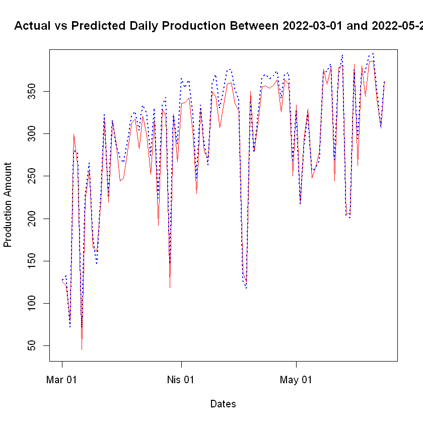

```r
plot(actual_sum$date,actual_sum$x,type='l',col = 'red',xlab= 'Dates',ylab='Production Amount',main='Actual vs Predicted Daily Production Between 2022-03-01 and 2022-05-24')
lines(predicted_sum$date,predicted_sum$x,lty=3,lwd=2,col='blue')
```

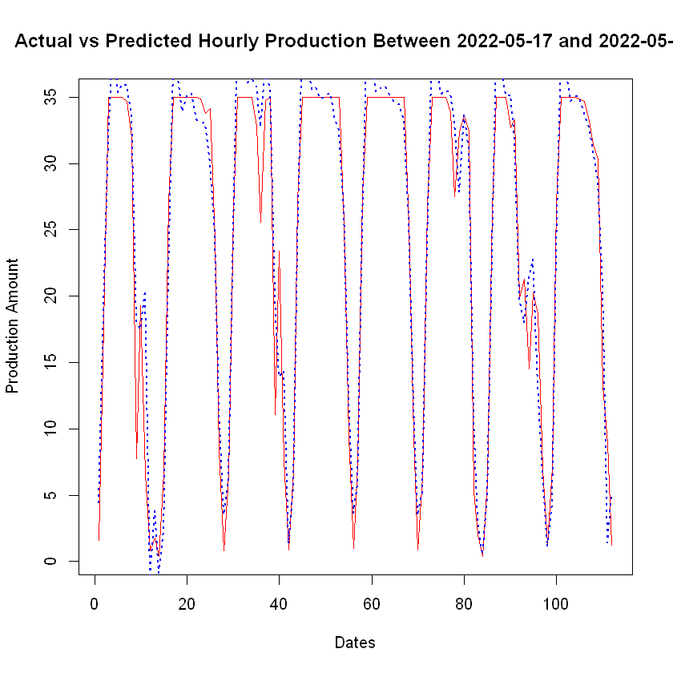

```r
plot(1:length(ev_model$production[which(ev_model$date == '2022-05-17'):length(ev_model$date)]),ev_model$production[which(ev_model$date == '2022-05-17')[1]:length(ev_model$date)],type='l',col = 'red',xlab= 'Dates',ylab='Production Amount',main='Actual vs Predicted Hourly Production Between 2022-05-17 and 2022-05-24')
lines(1:length(ev_model$predicted_prod[which(ev_model$date == '2022-05-17')[1]:length(ev_model$date)]),ev_model$predicted_prod[which(ev_model$date == '2022-05-17'):length(ev_model$date)],lty=3,lwd=2,col='blue')
```

From these 2 graphs, it can be shown that despite some disadvantages of our model it works quite well with the data. In these graphs, red lines show actual production volumes of the corresponding dates and hours and blue dashed lines shows predicted versions. At some points, there are some over and underpredictions but in general, it can be said that model works quite well with the data.

## Conclusion and Future Works

Eventhough plots tell that the final model works quite well for the given data, it is obvious this approach and model has disadvantages. First of all, as it is indicated before, the model that is choosen do not follow some properties. The residual analysis shows that the residuals are correlated (espicially at every lag 10) and they are not distributed normal. They are close to be normal but some rules are violated.

Also, it would better to indicate that models have been constructed in a heuristic manner. First empty dates are filled with 6 days averages. Then, weather variables are averaged and obtained as a single variable. Finally, a threshold for temperature values are determined by data driven and trial and error way. Other researches can determine other rules and obtain different results.

To obtain a better model, some new variables can introduced. For example, daily weather conditions(like sunny,foggy etc.) can obtain and related dummy variables can be introduced. Additionaly, there is no information about the plants conditions and their individual sizes, capacities etc.

Finally, in this project zero values from the data are dropped not to make models confused. Here, some spesific hours will be predicted. Except predicted hours, remaining hours will be automatically zero. In production phase, group1 floowed this manner. Lastly, as it is indicated before, during the prediction phase, models were changed as time passes. However, after some point, group1 decided to use this model with the prediction phase and hin this report this last model is introduced.

## Appendicies

Our code file is [here](https://bu-ie-360.github.io/spring22-DevrimKaradeniz/Project5.ipynb)

## References

https://otexts.com/fpp2/

https://www.bostonsolar.us/solar-blog-resource-center/blog/how-do-temperature-and-shade-affect-solar-panelefficiency/#:~:text=The%20temperature%20coefficient%20tells%20you,0.38%25%20per%20one%20degree%20Celsius